# act_report

## Report: act_report

- Introduction
- Method
- Analysis and Visualization
- Conclusion

### Introduction

The project analyzes the WeRateDogs twitter page. The datasets were gathered across different channels using the pandas and requests libraries as well as the Twitter API, tweepy. The homepage of the WeRateDogs Twitter channel is shown below.

[figure not shown]

A tweet showing the dog picture and rating on the WeRateDogs Twitter page

[figure not shown]

### Method

The data wrangling process included data assessment and data cleaning in an iterative manner. The cleaned data was stored in a csv file for reuse. The dataset contains information from `2166` tweets from the twitter channel of WeRateDogs and results from the neural network image prediction on the dogs pictures with 22 features.

### Analysis and Visualization:

The tweet with the highest favorite count and retweets is tweet_id: 744234799360020481, number of likes: 145002, number of retweets: 70821 as seen in the bar charts below.

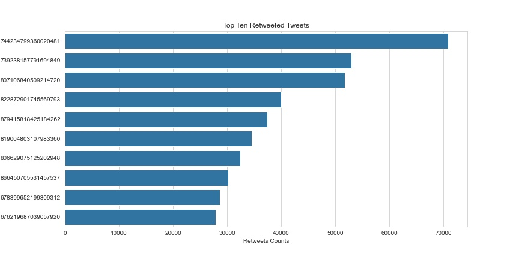

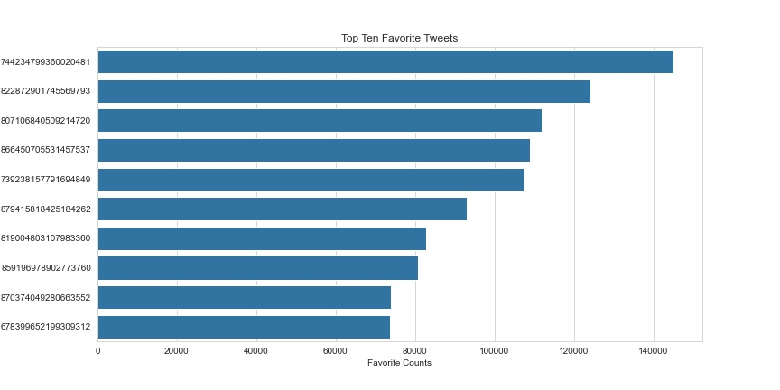

The most popular rating score for the dogs was 12 with count of 498. The majority of the rating ranged from 9 and 13. The plot showed outliers with ratings having few values above 500.

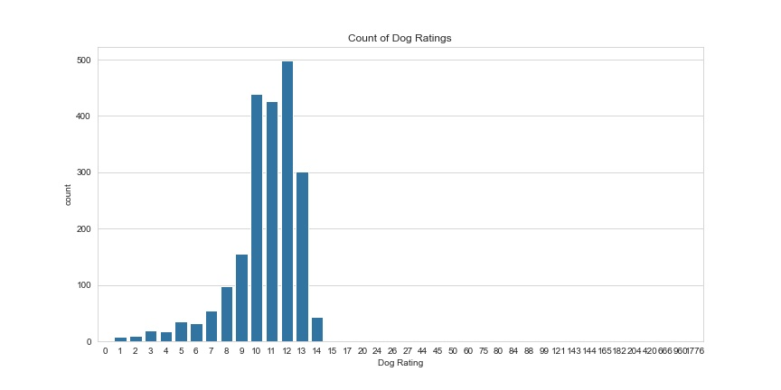

Pupper was the most common stage of dogs tweeted and posted on the WeRateDogs twitter channel while most tweets originated from the Twitter App for Iphones. This is as most people make use of social media applications on mobile phones and with the proliferation of Iphones among the teeming populace.

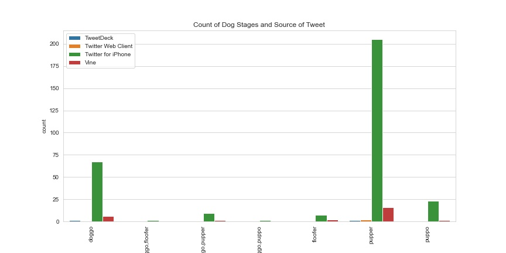

The scatter plot above shows that there is a correlation between the favorite count and retweet count. as the number of retweets increases, there is an increase in the number of likes. The more the retweets, the tweets reaches a wider audience which results in more likes.

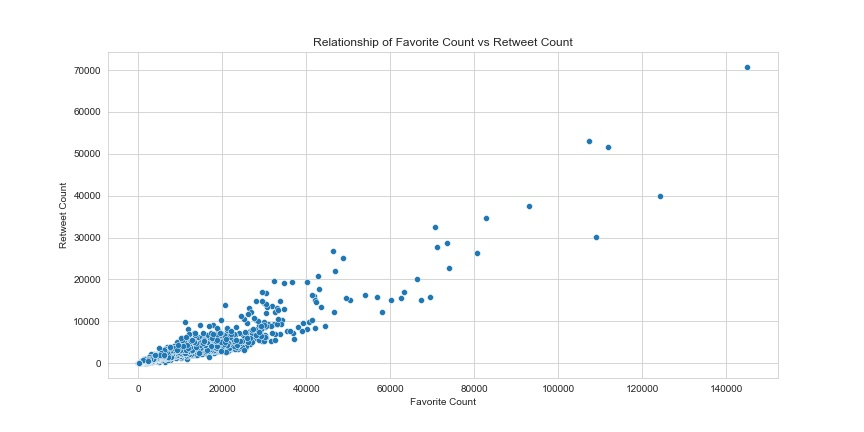

There is no correlation between the rating score and the number of likes nor the number of retweets as shown in the plot above.

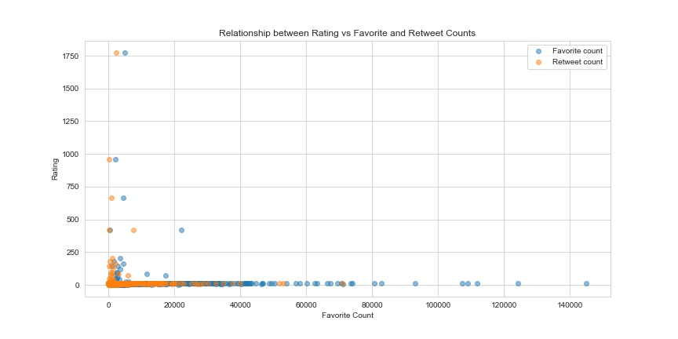

Golden Retriever was the most popular dog breed truly predicted in p1 in the dataset with 139 predictions as True and Labrador Retriever as the second on the list with 92.

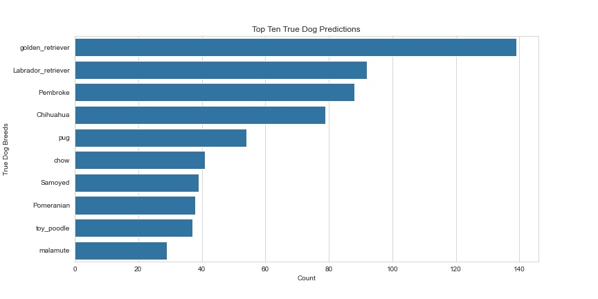

A Golden Retriever on a Sunny Day at the Beach

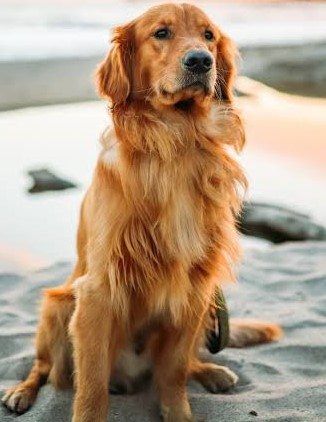

Seatbelt was the most popular false prediction in p1 in the dataset with 21 predictions as False and teddy as the second on the list with 18. 15 dogs were wrongly predicted as webs_site.

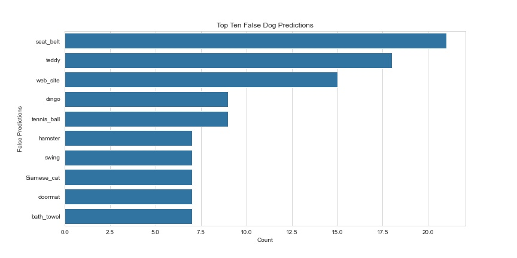

### Conclusion:

The project was completed by gathering data from 3 different sources. The data was assesses using both visualization and programmatic assessment. All quality and tidiness issues identified were cleaned and assessed.

Limitations observed include:

1. The dataset contained only few values in the dog stage. This could be further gotten from the text column in the dataset.
2. Some rating denominator and numerator have not been accurately extracted from the dataset.